# Structural Equation Modeling R Template

Jay Jeffries

1/13/2022

## Structural Equation Modeling in `Lavaan`

Data summary

| Name | BurnoutData |
| --- | --- |
| Number of rows | 876 |
| Number of columns | 25 |
| _______________________ |  |
| Column type frequency: |  |
| numeric | 25 |
| ________________________ |  |
| Group variables | None |

**Variable type: numeric**

| skim_variable | n_missing | complete_rate | mean | sd | p0 | p25 | p50 | p75 | p100 | hist |
| --- | --- | --- | --- | --- | --- | --- | --- | --- | --- | --- |
| schoolID | 0 | 1 | 29.43 | 17.63 | 1 | 13 | 30 | 45 | 60 | ▇▆▆▇▆ |
| districtID | 0 | 1 | 2.69 | 1.47 | 1 | 1 | 2 | 4 | 5 | ▇▆▃▅▅ |
| TSC1 | 0 | 1 | 3.65 | 0.68 | 1 | 3 | 4 | 4 | 5 | ▁▁▆▇▂ |
| TSC2 | 0 | 1 | 3.81 | 0.64 | 2 | 3 | 4 | 4 | 5 | ▁▃▁▇▂ |
| TSC3 | 0 | 1 | 3.73 | 0.64 | 2 | 3 | 4 | 4 | 5 | ▁▅▁▇▁ |
| TSC4 | 0 | 1 | 3.71 | 0.67 | 2 | 3 | 4 | 4 | 5 | ▁▅▁▇▂ |
| TSC5 | 0 | 1 | 3.82 | 0.65 | 2 | 3 | 4 | 4 | 5 | ▁▃▁▇▂ |
| TE1 | 0 | 1 | 4.06 | 0.71 | 1 | 4 | 4 | 5 | 5 | ▁▁▂▇▃ |
| TE2 | 0 | 1 | 4.04 | 0.70 | 2 | 4 | 4 | 5 | 5 | ▁▃▁▇▃ |
| TE3 | 0 | 1 | 4.12 | 0.71 | 1 | 4 | 4 | 5 | 5 | ▁▁▂▇▅ |
| TE4 | 0 | 1 | 4.11 | 0.69 | 1 | 4 | 4 | 5 | 5 | ▁▁▂▇▃ |
| TE5 | 0 | 1 | 3.90 | 0.75 | 1 | 3 | 4 | 4 | 5 | ▁▁▃▇▃ |
| EE1 | 0 | 1 | 3.81 | 0.76 | 1 | 3 | 4 | 4 | 5 | ▁▁▅▇▂ |
| EE2 | 0 | 1 | 3.73 | 0.85 | 1 | 3 | 4 | 4 | 5 | ▁▁▆▇▃ |
| EE3 | 0 | 1 | 3.88 | 0.83 | 1 | 3 | 4 | 4 | 5 | ▁▁▅▇▅ |
| EE4 | 0 | 1 | 3.69 | 0.80 | 1 | 3 | 4 | 4 | 5 | ▁▁▇▇▃ |
| EE5 | 0 | 1 | 3.99 | 0.81 | 1 | 3 | 4 | 5 | 5 | ▁▁▅▇▅ |
| DE1 | 0 | 1 | 3.92 | 0.68 | 1 | 4 | 4 | 4 | 5 | ▁▁▂▇▂ |
| DE2 | 0 | 1 | 3.60 | 0.68 | 1 | 3 | 4 | 4 | 5 | ▁▁▆▇▁ |
| DE3 | 0 | 1 | 3.82 | 0.70 | 1 | 3 | 4 | 4 | 5 | ▁▁▅▇▂ |
| RPA1 | 0 | 1 | 3.93 | 0.83 | 1 | 3 | 4 | 5 | 5 | ▁▁▅▇▅ |
| RPA2 | 0 | 1 | 3.94 | 0.80 | 1 | 4 | 4 | 4 | 5 | ▁▁▃▇▃ |
| RPA3 | 0 | 1 | 3.88 | 0.79 | 1 | 3 | 4 | 4 | 5 | ▁▁▃▇▃ |
| RPA4 | 0 | 1 | 3.87 | 0.76 | 1 | 3 | 4 | 4 | 5 | ▁▁▃▇▃ |
| RPA5 | 0 | 1 | 3.84 | 0.79 | 1 | 3 | 4 | 4 | 5 | ▁▁▃▇▃ |

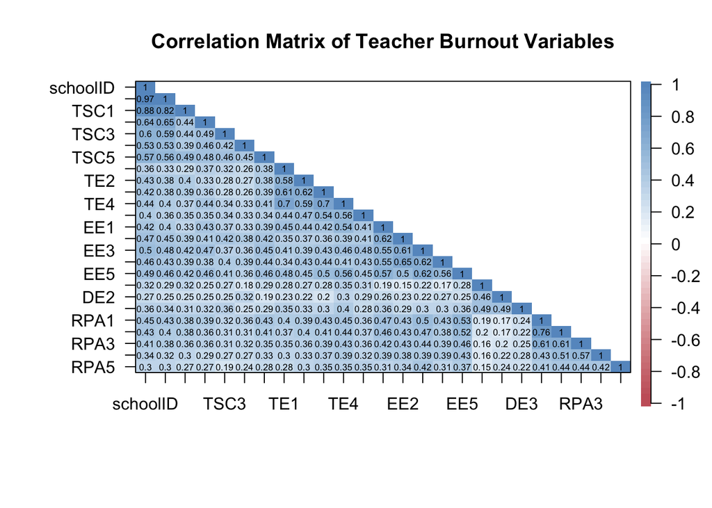

```
## $multivariateNormality
##              Test        Statistic p value Result
## 1 Mardia Skewness 10093.5982363133       0     NO
## 2 Mardia Kurtosis  40.745119199258       0     NO
## 3             MVN             <NA>    <NA>     NO
##
## $univariateNormality
##            Test   Variable Statistic   p value Normality
## 1  Shapiro-Wilk  schoolID     0.9412  <0.001      NO
## 2  Shapiro-Wilk districtID    0.8605  <0.001      NO
## 3  Shapiro-Wilk    TSC1       0.8187  <0.001      NO
## 4  Shapiro-Wilk    TSC2       0.7944  <0.001      NO
## 5  Shapiro-Wilk    TSC3       0.7938  <0.001      NO
## 6  Shapiro-Wilk    TSC4       0.8144  <0.001      NO
## 7  Shapiro-Wilk    TSC5       0.8020  <0.001      NO
## 8  Shapiro-Wilk    TE1        0.8149  <0.001      NO
## 9  Shapiro-Wilk    TE2        0.8168  <0.001      NO
## 10 Shapiro-Wilk    TE3        0.7914  <0.001      NO
## 11 Shapiro-Wilk    TE4        0.8032  <0.001      NO
## 12 Shapiro-Wilk    TE5        0.8378  <0.001      NO
## 13 Shapiro-Wilk    EE1        0.8431  <0.001      NO
## 14 Shapiro-Wilk    EE2        0.8668  <0.001      NO
## 15 Shapiro-Wilk    EE3        0.8592  <0.001      NO
## 16 Shapiro-Wilk    EE4        0.8591  <0.001      NO
## 17 Shapiro-Wilk    EE5        0.8466  <0.001      NO
## 18 Shapiro-Wilk    DE1        0.7955  <0.001      NO
## 19 Shapiro-Wilk    DE2        0.8070  <0.001      NO
## 20 Shapiro-Wilk    DE3        0.8221  <0.001      NO
## 21 Shapiro-Wilk    RPA1       0.8455  <0.001      NO
## 22 Shapiro-Wilk    RPA2       0.8272  <0.001      NO
## 23 Shapiro-Wilk    RPA3       0.8384  <0.001      NO
## 24 Shapiro-Wilk    RPA4       0.8384  <0.001      NO
## 25 Shapiro-Wilk    RPA5       0.8413  <0.001      NO
##
## $Descriptives
##              n      Mean    Std.Dev Median Min Max 25th 75th        Skew
## schoolID   876 29.425799 17.6282947     30   1  60   13   45  0.04592988
## districtID 876  2.694064  1.4673627      2   1   5    1    4  0.29419651
## TSC1       876  3.652968  0.6849419      4   1   5    3    4 -0.09242437
## TSC2       876  3.809361  0.6388948      4   2   5    3    4 -0.07293765
```

[output cut: 32 more lines]

```
## TE4         0.50711668
## TE5         0.16474956
## EE1         0.23143832
## EE2         0.12256023
## EE3        -0.39901657
## EE4        -0.40742547
## EE5        -0.26944283
## DE1         1.24559696
## DE2         0.63925394
## DE3         0.01245932
## RPA1        0.50420600
## RPA2        1.22272528
## RPA3        0.74890573
## RPA4        0.33329229
## RPA5        0.67055640
```

```r
colors <- colorRampPalette(c("#B52127", "white", "#2171B5"))
cor.plot(BurnoutData, upper = FALSE, main = "Correlation Matrix of Teacher Burnout Variables", gr = colors)
```

### Model Specification

#### Building the Model

The obtained data has 5 latent variables inherent in the measures. These are: teacher self-concept, efficacy, emotional exhaustion, depersonalization, and a reduced sense of personal accomplishment. Teacher self-concept (TSC1-TSC5) and self-efficacy (TE1-TE5) predict teacher burnout. Teacher burnout is composed of emotional exhaustion (EE1-EE5), depersonalization (DE1-DE3), and a reduced sense of personal accomplishment (RPA1-RPA5). Below is a table of commands to help us build this model. This dataset was adapted to include the feaux variables schoolID and districtID for demonstrative purposes.

| formula type | operator | mnemonic |
| --- | --- | --- |
| latent variable definition | =~ | is measured by |
| regression | ~ | is regressed on |
| (residual) (co)variance | ~~ | is correlated with |
| intercept | ~ 1 | intercept |

```r
model <- '
SelfConcept =~ TSC1 + TSC2 + TSC3 + TSC4 + TSC5
TeacherEfficacy =~ TE1 + TE2 + TE3 + TE4 + TE5
EmotionalExhaustion =~ EE1 + EE2 + EE3 + EE4 + EE5
Depersonalization =~ DE1 + DE2 + DE3
ReducedAccomplishment =~ RPA1 + RPA2 + RPA3 + RPA4 + RPA5
Burnout =~ EmotionalExhaustion + Depersonalization + ReducedAccomplishment
Burnout ~ SelfConcept + TeacherEfficacy
'
# FACTOR LOADINGS
# To fix a factor loading to 1, multiply factor by 1 (e.g. Burnout =~ 1*EmotionalExhaustion + Depersonalization + ReducedAccomplishment)
    # In this case, the regression coefficient from Burnout to Emotional Exhaustion was set equal to 1.
    # In the sem() function below, std.lv = TRUE allows the first indicator of each latent variable to be unconstrained.
# Equality constraints can be placed on indicators via: Depersonalization =~ DE1 + DE2 + DE2*DE3
  # In this case, DE2 and DE3 loadings are set to be equal.
  # Similarly, Depersonalization =~ DE1 + DE2 + equal("Depersonalization=~DE2")*DE3  performs the same thing

# FACTOR CO(VARIANCES)
# To make factors orthogonal (correlation of 0), add a covariance formula (e.g. EmotionalExhaustion ~~ 0*Depersonalization)
    # If all factors are to be orthogonal, a shortcut included in the sem() function below is to add orthogonal = TRUE

# FACTOR VARIANCES
# To fix the variance of a factor, elicit this in a formula akin to EmotionalExhaustion ~~ 1*EmotionalExhaustion

# Unstandardized solution
fit_model <- sem(model, data = BurnoutData, std.lv = TRUE, estimator = "MLM")
# MLM is used due to non-normal data and also provides robust SE's and scaled test statistics, which helps to address these assumption violations.

# Standardized solution
standardizedsolution(fit_model, type = "std.all", se = TRUE, zstat = TRUE, pvalue = TRUE, ci = TRUE) %>%
  filter(op == "=~") %>%
  select(Latent_Var = lhs, Item = rhs, Coefficient = est.std, ci.lower, ci.upper, SE = se, Z = z, 'p-value' = pvalue)
```

```
##               Latent_Var                  Item Coefficient ci.lower ci.upper
## 1            SelfConcept                  TSC1       0.659    0.614    0.705
## 2            SelfConcept                  TSC2       0.703    0.659    0.748
## 3            SelfConcept                  TSC3       0.659    0.611    0.707
## 4            SelfConcept                  TSC4       0.620    0.567    0.673
## 5            SelfConcept                  TSC5       0.715    0.674    0.756
## 6        TeacherEfficacy                   TE1       0.770    0.731    0.809
## 7        TeacherEfficacy                   TE2       0.728    0.691    0.765
## 8        TeacherEfficacy                   TE3       0.806    0.771    0.840
## 9        TeacherEfficacy                   TE4       0.862    0.835    0.888
## 10       TeacherEfficacy                   TE5       0.657    0.605    0.708
## 11   EmotionalExhaustion                   EE1       0.749    0.712    0.787
## 12   EmotionalExhaustion                   EE2       0.758    0.723    0.794
## 13   EmotionalExhaustion                   EE3       0.789    0.757    0.821
## 14   EmotionalExhaustion                   EE4       0.764    0.725    0.803
```

[output cut: 39 more lines]

```r
summary(fit_model, standardized = TRUE)
```

```
## lavaan 0.6-9 ended normally after 69 iterations
##
##   Estimator                                         ML
##   Optimization method                           NLMINB
##   Number of model parameters                        52
##
##   Number of observations                           876
##
## Model Test User Model:
##                                               Standard      Robust
##   Test Statistic                               906.306     771.870
##   Degrees of freedom                               224         224
##   P-value (Chi-square)                           0.000       0.000
##   Scaling correction factor                                  1.174
##        Satorra-Bentler correction
##
## Parameter Estimates:
##
##   Standard errors                           Robust.sem
##   Information                                 Expected
##   Information saturated (h1) model          Structured
##
## Latent Variables:
##                            Estimate  Std.Err  z-value  P(>|z|)   Std.lv
##   SelfConcept =~
##     TSC1                      0.451    0.021   21.789    0.000    0.451
##     TSC2                      0.449    0.020   22.281    0.000    0.449
##     TSC3                      0.421    0.022   18.837    0.000    0.421
##     TSC4                      0.417    0.023   18.230    0.000    0.417
##     TSC5                      0.466    0.021   22.711    0.000    0.466
##   TeacherEfficacy =~
##     TE1                       0.548    0.025   22.186    0.000    0.548
##     TE2                       0.508    0.020   25.898    0.000    0.508
##     TE3                       0.568    0.027   20.992    0.000    0.568
##     TE4                       0.594    0.022   26.668    0.000    0.594
##     TE5                       0.495    0.027   18.304    0.000    0.495
##   EmotionalExhaustion =~
##     EE1                       0.252    0.018   14.359    0.000    0.568
##     EE2                       0.286    0.020   14.086    0.000    0.643
##     EE3                       0.290    0.020   14.164    0.000    0.653
```

[output cut: 77 more lines]

```
##    .EE5               0.272    0.019   14.279    0.000    0.272    0.414
##    .DE1               0.260    0.017   14.906    0.000    0.260    0.567
##    .DE2               0.264    0.015   17.504    0.000    0.264    0.567
##    .DE3               0.210    0.021    9.794    0.000    0.210    0.431
##    .RPA1              0.207    0.015   13.816    0.000    0.207    0.298
##    .RPA2              0.178    0.014   12.498    0.000    0.178    0.275
##    .RPA3              0.270    0.029    9.438    0.000    0.270    0.434
##    .RPA4              0.359    0.027   13.099    0.000    0.359    0.614
##    .RPA5              0.431    0.031   14.004    0.000    0.431    0.699
##     SelfConcept       1.000                               1.000    1.000
##     TeacherEfficcy    1.000                               1.000    1.000
##    .EmotionlExhstn    1.000                               0.197    0.197
##    .Depersonaliztn    1.000                               0.636    0.636
##    .RdcdAccmplshmn    1.000                               0.396    0.396
##    .Burnout           1.000                               0.125    0.125
```

```r
parameterEstimates(fit_model, standardized = TRUE, rsquare = TRUE) %>%
  filter(op == "r2") %>%
  select(Item = rhs, R2 = est)
```

```
##                     Item    R2
## 1                   TSC1 0.435
## 2                   TSC2 0.495
## 3                   TSC3 0.434
## 4                   TSC4 0.385
## 5                   TSC5 0.511
## 6                    TE1 0.593
## 7                    TE2 0.530
## 8                    TE3 0.649
## 9                    TE4 0.743
## 10                   TE5 0.431
## 11                   EE1 0.561
## 12                   EE2 0.575
## 13                   EE3 0.623
## 14                   EE4 0.584
## 15                   EE5 0.586
## 16                   DE1 0.433
## 17                   DE2 0.433
## 18                   DE3 0.569
## 19                  RPA1 0.702
## 20                  RPA2 0.725
## 21                  RPA3 0.566
## 22                  RPA4 0.386
## 23                  RPA5 0.301
## 24   EmotionalExhaustion 0.803
## 25     Depersonalization 0.364
## 26 ReducedAccomplishment 0.604
## 27               Burnout 0.875
```

Overall, the model accounted for 87.5% of variance in Teacher Burnout.

```r
lavaanPlot(model = fit_model, node_options = list(shape = "box", fontname = "Times"), edge_options = list(color = "grey"), coefs = TRUE, stand = TRUE, sig = .05)
```

[interactive chart not shown]

Structural Equation Model of Teacher Burnout

```r
# Note: this code chunk is suppressed due to the space it takes up, delete `eval = FALSE` to print

fitted(fit_model) # Model-implied (fitted) covariance matrix with mean vector.

vcov(fit_model) # Estimated covariance matrix of the parameter estimates.
```

### Fit Statistics

#### Assessing Model Suitability

```r
fitMeasures(fit_model, c("chisq.scaled", "df.scaled", "pvalue.scaled"))
```

```
##  chisq.scaled     df.scaled pvalue.scaled
##        771.87        224.00          0.00
```

```r
fitMeasures(fit_model, c("rmsea.scaled", "rmsea.ci.lower.scaled", "rmsea.ci.upper.scaled", "rmsea.pvalue.scaled"))
```

```
##          rmsea.scaled rmsea.ci.lower.scaled rmsea.ci.upper.scaled
##                 0.053                 0.049                 0.057
##   rmsea.pvalue.scaled
##                 0.105
```

The root mean square error of approximation (RMSEA) is a popular measure of the discrepancy between the model-based and observed correlation matrices. It uses the model chi-square in its computation but makes adjustments based on model complexity (parsimony-adjusted) and has a known sampling distribution so it is possible to compute confidence intervals. It is often the goal to obtain an RMSEA <= .05, where RMSEA between .05 - .08 exhibits reasonable fit, and .10 or above as poor fit (Brown & Cudeck, 1993). Between the .08 and .10 is a “gray area”. The results ($RMSEA = .053$) indicate a reasonable to well-fitting model, which is supported by the non-significant *p*-value that supports a close fit model.

```r
fitMeasures(fit_model, c("cfi.scaled", "srmr"))
```

```
## cfi.scaled       srmr
##      0.920      0.043
```

The CFI is an index that compares the proposed model’s covariance matrix to an independent (“restricted”, “null”, “baseline”, complately uncorrelated) covariance matrix. To be considered good fit, the aim of a Comparitive Fit Index value is .95 or above (Hu & Bentler, 1999). This CFI estimate ($CFI = .92$) shows that the model does not have *close fit* to the data.

The standardized root mean residual,SRMR, is based on the actual differences (discrepancies) between the model-based covariances and the actual covariances. This statistic finds the average difference between the average squared covariances in the sample and population through use of the standardized residuals of the model. Its standardization is useful, as it can interpret variables whose values are not on the same metric. It is common practice to determine that the mean correlation residual SRMR <= .08 indicates good fit (Hu & Bentler, 1999), but SRMR can range from 0 to 1. This statistic ($SRMR = .043$) compares our model to a perfectly saturated model, and determines that the analyzed covariance matrix from this model nicely fits the implied covariance matrix from the data.

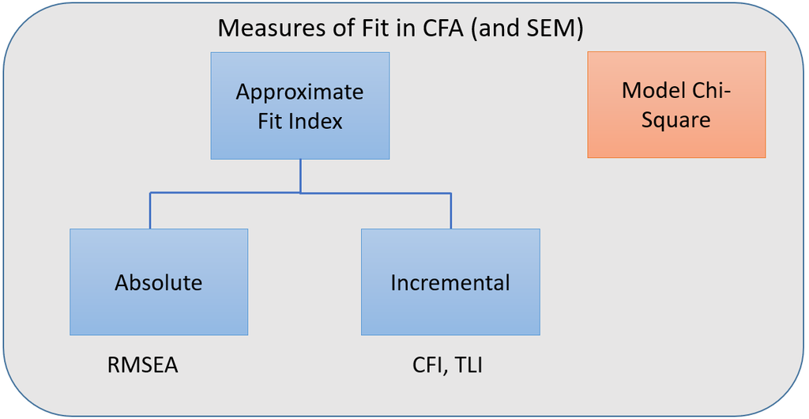

```r
AIC(fit_model)
```

```
## [1] 35229.31
```

```r
BIC(fit_model)
```

```
## [1] 35477.63
```

### Modification Indices

```r
modindices(fit_model, sort = TRUE, maximum.number = 5) # Top 5 recommended model modifications
```

```
##         lhs op  rhs      mi    epc sepc.lv sepc.all sepc.nox
## 417    RPA1 ~~ RPA2 112.016  0.136   0.136    0.709    0.709
## 419    RPA1 ~~ RPA4  63.327 -0.096  -0.096   -0.351   -0.351
## 165 Burnout =~  EE5  51.701  0.193   0.546    0.674    0.674
## 363     EE2 ~~  EE5  50.037 -0.086  -0.086   -0.299   -0.299
## 424    RPA3 ~~ RPA4  44.963  0.082   0.082    0.264    0.264
```

```r
mi <- modindices(fit_model)

# You can specialize type of mod indices by statistic (e.g. correlation, regression coeff's, etc.)

MILoadings <- mi[mi$op == "=~",] # These are mod indices for factor loading regression coefficients only
MICovars <- mi[mi$op == "~~",] # These are mod indices for residual covariances (correlations) only

# MILoadings   # These output are suppressed due to their size
# MICovars
```

### Starting Values for Model Parameters

https://lavaan.ugent.be/tutorial/syntax2.html

```r
SelfConcept =~ TSC1 + start(0.5)*TSC2 + start(0.6)*TSC3 + start(0.7)*TSC4 + start(0.8)*TSC5
TeacherEfficacy =~ TE1 + start(0.3)*TE2 + TE3 + TE4 + start(0.5)*TE5
Burnout ~ SelfConcept + TeacherEfficacy
```

Start values can be placed on factor loadings by using the function `start()`.

## Multilevel Structural Equation Model

#### Acknowledging Nested Data

```r
model2 <- '
level: 1
SelfConcept =~ TSC1 + TSC2 + TSC3 + TSC4 + TSC5
TeacherEfficacy =~ TE1 + TE2 + TE3 + TE4 + TE5
TeacherEfficacy ~ SelfConcept
EmotionalExhaustion =~ EE1 + EE2 + EE3 + EE4 + EE5
Depersonalization =~ DE1 + DE2 + DE3
ReducedAccomplishment =~ RPA1 + RPA2 + RPA3 + RPA4 + RPA5

level: 2
Burnout =~ EE1 + EE2 + EE3 + EE4 + EE5 + DE1 + DE2 + DE3 + RPA1 + RPA2 + RPA3 + RPA4 + RPA5
'

fit_MSEM <- sem(model = model2, data = BurnoutData, cluster = "schoolID")

summary(fit_MSEM, fit.measures=TRUE)
```

```
## lavaan 0.6-9 ended normally after 211 iterations
##
##   Estimator                                         ML
##   Optimization method                           NLMINB
##   Number of model parameters                       102
##
##   Number of observations                           876
##   Number of clusters [schoolID]                     60
##
## Model Test User Model:
##
##   Test statistic                              1001.133
##   Degrees of freedom                               288
##   P-value (Chi-square)                           0.000
##
## Model Test Baseline Model:
##
##   Test statistic                              8705.572
##   Degrees of freedom                               331
##   P-value                                        0.000
##
## User Model versus Baseline Model:
##
##   Comparative Fit Index (CFI)                    0.915
##   Tucker-Lewis Index (TLI)                       0.902
##
## Loglikelihood and Information Criteria:
##
##   Loglikelihood user model (H0)             -17493.887
##   Loglikelihood unrestricted model (H1)     -16993.320
##
##   Akaike (AIC)                               35191.774
##   Bayesian (BIC)                             35678.861
##   Sample-size adjusted Bayesian (BIC)        35354.932
##
## Root Mean Square Error of Approximation:
##
##   RMSEA                                          0.053
##   90 Percent confidence interval - lower         0.050
##   90 Percent confidence interval - upper         0.057
```

[output cut: 164 more lines]

```
##                    Estimate  Std.Err  z-value  P(>|z|)
##    .EE1               0.016    0.008    2.064    0.039
##    .EE2               0.017    0.008    2.185    0.029
##    .EE3               0.011    0.006    1.722    0.085
##    .EE4               0.015    0.007    2.121    0.034
##    .EE5               0.031    0.010    3.181    0.001
##    .DE1               0.028    0.009    2.984    0.003
##    .DE2               0.009    0.006    1.419    0.156
##    .DE3               0.005    0.006    0.889    0.374
##    .RPA1              0.009    0.005    1.667    0.095
##    .RPA2              0.010    0.006    1.667    0.096
##    .RPA3              0.002    0.006    0.378    0.705
##    .RPA4              0.004    0.007    0.572    0.567
##    .RPA5              0.011    0.008    1.377    0.168
##     Burnout           0.015    0.010    1.496    0.135
```

```r
lavaanPlot(model = fit_MSEM, node_options = list(shape = "box", fontname = "Times"), edge_options = list(color = "grey"), coefs = TRUE, stand = TRUE, sig = .05)
```

[interactive chart not shown]

## Model Fit Statistics

Model chi-square is the chi-square statistic we obtain from the maximum likelihood statistic

- in `lavaan`, this is known as the Test Statistic for the Model Test User Model
- It is well documented in CFA and SEM literature that the chi-square is often overly sensitive in model testing especially for large samples. [David Kenny](http://www.davidakenny.net/cm/fit.htm) states that for models with 75 to 200 cases chi-square is a reasonable measure of fit, but for 400 cases or more it is nearly almost always significant
- If CFI = 0, then it means that the user’s model is misspecified.

CFI is the Comparative Fit Index

- values can range between 0 and 1 (values greater than 0.90 are adequate, conservatively 0.95 indicate good fit).

TLI Tucker Lewis Index ranges between 0 and 1 (if it’s greater than 1 it should be rounded to 1) with values greater than 0.90 indicating good fit.

- The CFI is always greater than the TLI.
- If you reject the model, it means your model is not a close fitting model.
- The term used in the TLI is the “relative chi-square” (i.e. normed chi-square) and is less sensitive to sample size.
- You can think of the TLI as the ratio of the deviation of the null (baseline) model from user model to the deviation of the baseline (or null) model to the perfect fit model.
- Because the TLI and CFI are highly correlated, only one of the two should be reported.

- The root mean square error of approximation is an absolute measure of fit because it does not compare the discrepancy of the user model relative to a baseline model (like the CFI or TLI). Instead, RMSEA defines as the non-centrality parameter which measures the degree of misspecification.
  - $\leq .05$ indicates close-fit
  - between $.05$ to $.08$ indicates reasonable approximate fit; fails close-fit but also fails poor-fit
  - $\geq .10$ indicates (poor-fit)

```r
lavInspect(fit_MSEM, "icc") # Intraclass correlations
```

```
##  TSC1  TSC2  TSC3  TSC4  TSC5   TE1   TE2   TE3   TE4   TE5   EE1   EE2   EE3
## 0.000 0.000 0.000 0.000 0.000 0.000 0.000 0.000 0.000 0.000 0.057 0.043 0.031
##   EE4   EE5   DE1   DE2   DE3  RPA1  RPA2  RPA3  RPA4  RPA5
## 0.037 0.037 0.078 0.033 0.038 0.036 0.058 0.054 0.053 0.054
```

```r
# lavInspect(fit_MSEM, "h1") # Unrestricted within- and between-means and covariances

# modindices(fit_MSEM, sort = TRUE)
modindices(fit_MSEM, sort = TRUE, maximum.number = 5) # Top 5 recommended model modifications
```

```
##             lhs op             rhs block group level      mi    epc sepc.lv
## 463        RPA1 ~~            RPA2     1     1     1 109.080  0.130   0.130
## 477 SelfConcept  ~ TeacherEfficacy     1     1     1  81.646 -0.379  -0.469
## 473 SelfConcept ~~ TeacherEfficacy     1     1     1  81.645 -0.050  -0.310
## 465        RPA1 ~~            RPA4     1     1     1  57.687 -0.089  -0.089
## 409         EE2 ~~             EE5     1     1     1  48.386 -0.080  -0.080
##     sepc.all sepc.nox
## 463    0.719    0.719
## 477   -0.469   -0.469
## 473   -0.310   -0.310
## 465   -0.339   -0.339
## 409   -0.304   -0.304
```

## Resources

[Lavaan package documentation](https://lavaan.ugent.be/tutorial/inspect.html)

[UCLA Introduction to SEM in R with Lavaan](https://stats.oarc.ucla.edu/r/seminars/rsem/)

[Using R for Social Work Research, Chapter 5](https://bookdown.org/bean_jerry/using_r_for_social_work_research/structural-equation-modeling.html)